# PracticaFinal_Alba

## Práctica Final: clasificación MultiLabel

### Estudiante: Andrés Alba

### Explicacion del dataset

Importamos las librerias

```python
import os
import pathlib
import pandas as pd
import numpy as np
import copy
import re
import pandas as pd
import numpy as np
from sklearn.feature_extraction.text import CountVectorizer
from keras.preprocessing.text import Tokenizer
from tensorflow.keras.preprocessing.sequence import pad_sequences
from sklearn.preprocessing import MultiLabelBinarizer
import matplotlib.pyplot as plt
from sklearn.feature_extraction.text import TfidfVectorizer

from keras.models import Sequential
from keras.layers import Dense, Embedding, LSTM, SpatialDropout1D
from sklearn.model_selection import train_test_split
from sklearn.metrics import classification_report

import re
from keras.models import model_from_json
from keras.models import load_model
from pandas import DataFrame
from sklearn.metrics import accuracy_score

from sklearn.metrics import hamming_loss

import nltk
nltk.download('stopwords')
nltk.download('wordnet')
from nltk.stem.wordnet import WordNetLemmatizer
import numpy as np
import re
from nltk.corpus import stopwords
from nltk.stem.porter import PorterStemmer
from string import punctuation
from nltk.stem.porter import PorterStemmer
from sklearn.multioutput import MultiOutputClassifier
from sklearn.linear_model import LogisticRegression
from sklearn.ensemble import RandomForestClassifier

import sqlite3
import pickle
import nltk
from nltk.corpus import stopwords
nltk.download('stopwords')

print ('********** Módulos importados')
```

```
WARNING:tensorflow:From D:\anaconda3\Lib\site-packages\keras\src\losses.py:2976: The name tf.losses.sparse_softmax_cross_entropy is deprecated. Please use tf.compat.v1.losses.sparse_softmax_cross_entropy instead.

********** Módulos importados
```

#### Carga del dataset

```python
train_file = 'DBP_wiki_data.csv'
df = pd.read_csv(train_file)
df.rename(columns = {'text':'Texts','l1':'clase', 'l2':'profession','l3':'Type'}, inplace = True)

print("Shape:")
print("Train:{} ".format(df.shape))
```

```
Shape:
Train:(342781, 6)
```

```python
df.head()
```

|  | Texts | clase | profession | Type | wiki_name | word_count |
| --- | --- | --- | --- | --- | --- | --- |
| 0 | The 1994 Mindoro earthquake occurred on Novemb... | Event | NaturalEvent | Earthquake | 1994_Mindoro_earthquake | 59 |
| 1 | The 1917 Bali earthquake occurred at 06:50 loc... | Event | NaturalEvent | Earthquake | 1917_Bali_earthquake | 68 |
| 2 | The 1941 Colima earthquake occurred on April 1... | Event | NaturalEvent | Earthquake | 1941_Colima_earthquake | 194 |
| 3 | The 1983 Coalinga earthquake occurred on May 2... | Event | NaturalEvent | Earthquake | 1983_Coalinga_earthquake | 98 |
| 4 | The 2013 Bushehr earthquake occurred with a mo... | Event | NaturalEvent | Earthquake | 2013_Bushehr_earthquake | 61 |

### Mostramos los valores unicos de las 3 clases

```python
df['clase'].value_counts()
```

```
clase
Agent             177341
Place              65128
Species            31149
Work               29832
Event              27059
SportsSeason        8307
UnitOfWork          2497
TopicalConcept      1115
Device               353
Name: count, dtype: int64
```

```python
df['profession'].unique()
```

```
array(['NaturalEvent', 'SocietalEvent', 'SportsEvent', 'Olympics',
       'Tournament', 'Race', 'SportsTeamSeason', 'FootballLeagueSeason',
       'Software', 'Database', 'Song', 'MusicalWork', 'WrittenWork',
       'PeriodicalLiterature', 'Comic', 'Cartoon', 'Genre',
       'FloweringPlant', 'Plant', 'Animal', 'Horse', 'Eukaryote', 'Tower',
       'Venue', 'AmusementParkAttraction', 'Infrastructure', 'Station',
       'RouteOfTransportation', 'SportFacility', 'RaceTrack', 'Building',
       'EducationalInstitution', 'NaturalPlace', 'Stream', 'BodyOfWater',
       'CelestialBody', 'Satellite', 'Settlement',
       'ClericalAdministrativeRegion', 'Engine', 'LegalCase', 'Person',
       'OrganisationMember', 'SportsManager', 'Coach', 'Writer',
       'Politician', 'Cleric', 'Presenter', 'Athlete', 'Wrestler',
       'GridironFootballPlayer', 'Boxer', 'VolleyballPlayer',
       'MotorcycleRider', 'RacingDriver', 'WinterSportPlayer',
       'BritishRoyalty', 'Artist', 'MusicalArtist', 'Actor', 'Scientist',
       'FictionalCharacter', 'ComicsCharacter', 'Organisation', 'Company',
       'Group', 'SportsLeague', 'SportsTeam', 'Broadcaster'], dtype=object)
```

```python
df['Type'].value_counts()
```

```
Type
Planet                   2700
FootballMatch            2700
Manga                    2700
GolfPlayer               2700
AcademicJournal          2700
                         ...
Cycad                     204
AnimangaCharacter         203
BeachVolleyballPlayer     194
CanadianFootballTeam      190
BiologicalDatabase        187
Name: count, Length: 219, dtype: int64
```

##### Realizamos el limpiado del texto eliminando signos como las comas, puntos, parentesis etc, y realizo la normalización unicode y al despues codifico en Ascci el texto y al darle el 'ignore' cualquier caracter que no pueda ser representado con Ascci se ignorara y que se decodifique en UTF-8

```python
import unicodedata
import re

lemmatizer = WordNetLemmatizer()
stop_words = set(stopwords.words('english'))
porter = PorterStemmer()

def normalizer(s):
    replacements = (
        ("á", "a"),
        ("é", "e"),
        ("í", "i"),
        ("ó", "o"),
        ("ú", "u"),
        ("à", "a"),
        ("è", "e"),
        ("ì", "i"),
        ("ò", "o"),
        ("ù", "u"),
        #("ñ", "n"),
    )
    for a, b in replacements:
        s = s.replace(a, b).replace(a.upper(), b.upper())
    return s


def clean_it(text, normalize=True):
    if isinstance(text, str):  # Verificar si es una cadena de caracteres

        text = re.sub(r'[,":;()\[\]{}!?\.\'\\-]', ' ', text)
        text=re.sub("&lt;/?.*?&gt;"," &lt;&gt; ",text) #remove tags
        text = re.sub('<[^>]*>', '', text)
        emoticons = re.findall('(?::|;|=)(?:-)?(?:\)|\(|D|P)', text.lower())
        text = re.sub('[\W]+', ' ', text.lower()) + ' '.join(emoticons).replace('-', '')
        text = normalizer(text)
        text=re.sub("(\\d|\\W)+"," ",text)
        text = re.sub(r'\s+', ' ', text)  # Eliminar espacios múltiples
        text = text.strip().lower()  # Convertir a minúsculas y eliminar espacios en blanco al inicio y al final

        words = text.split()
        words = [lemmatizer.lemmatize(word) for word in words if word not in stop_words]

        text = ' '.join(words)

        if normalize:
            # Normalizar Unicode
            text = unicodedata.normalize('NFKD', text).encode('ascii', 'ignore').decode('utf-8')
    else:
        print("El texto no es una cadena de caracteres.")

    return text


df['Texts'] = df['Texts'].apply(lambda x: clean_it(x,True))
```

```python
df.head()
```

|  | Texts | clase | profession | Type | wiki_name | word_count |
| --- | --- | --- | --- | --- | --- | --- |
| 0 | mindoro earthquake occurred november local tim... | Event | NaturalEvent | Earthquake | 1994_Mindoro_earthquake | 59 |
| 1 | bali earthquake occurred local time january ja... | Event | NaturalEvent | Earthquake | 1917_Bali_earthquake | 68 |
| 2 | colima earthquake occurred april utc local tim... | Event | NaturalEvent | Earthquake | 1941_Colima_earthquake | 194 |
| 3 | coalinga earthquake occurred may exactly utc c... | Event | NaturalEvent | Earthquake | 1983_Coalinga_earthquake | 98 |
| 4 | bushehr earthquake occurred moment magnitude a... | Event | NaturalEvent | Earthquake | 2013_Bushehr_earthquake | 61 |

En los primeros entrenamientos se obtuvieron resultados muy pobres al combinar I1,I2,I3 por lo que se opto por solo combinar I1 e I2 lo cual nos dio mucho mejores resultado dandonos un total de 79 labels

```python
y_dat= df[['clase', 'profession']].values
```

```python
y_dat
```

```
array([['Event', 'NaturalEvent'],
       ['Event', 'NaturalEvent'],
       ['Event', 'NaturalEvent'],
       ...,
       ['Agent', 'Broadcaster'],
       ['Agent', 'Broadcaster'],
       ['Agent', 'Broadcaster']], dtype=object)
```

### Analisis de Frecuencia del dataset y muestreo

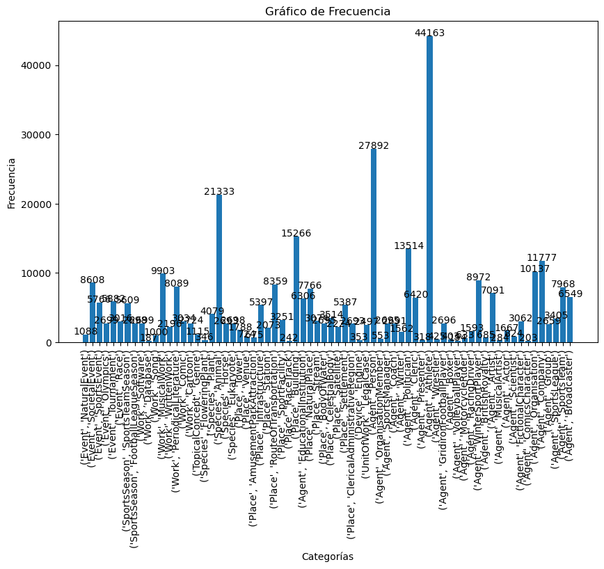

```python
import matplotlib.pyplot as plt
from collections import Counter

Y = [tuple(item) for item in df[['clase', 'profession']].values.tolist()]

frecuencias = Counter(Y)

elementos = list(frecuencias.keys())
frecuencias = list(frecuencias.values())

# Convertir elementos en cadenas
elementos = [str(elem) for elem in elementos]

plt.figure(figsize=(10, 6))
plt.bar(elementos, frecuencias)

plt.xlabel('Categorías')
plt.ylabel('Frecuencia')
plt.title('Gráfico de Frecuencia')

plt.xticks(rotation=90)  # Rotar las etiquetas del eje x para mayor claridad

for i, v in enumerate(frecuencias):
    plt.text(i, v + 0.1, str(v), ha='center')

plt.show()
```

Se realiza un balanceamiento de datos para buscar equilibrarlo un poco

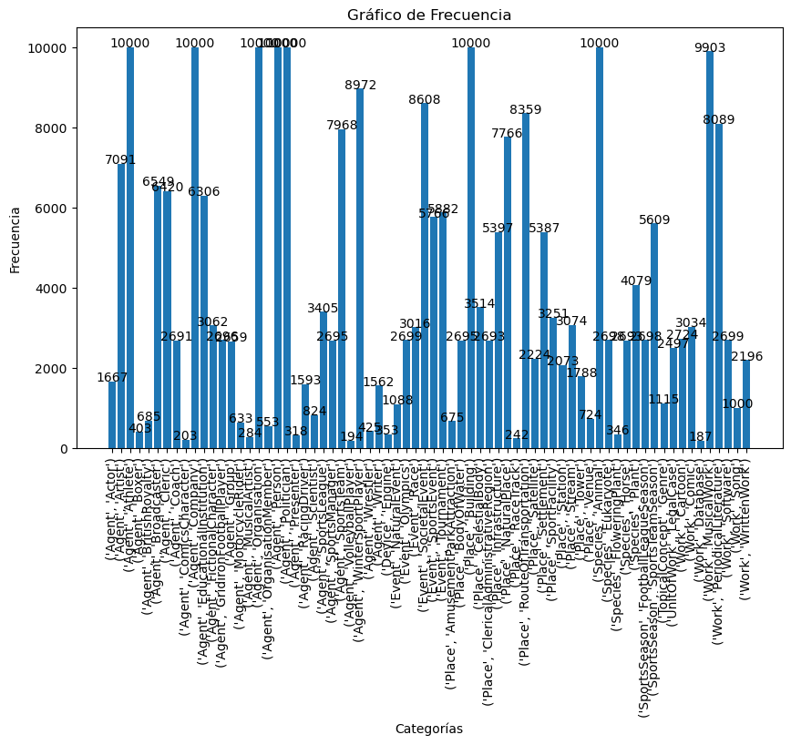

```python
import pandas as pd
import matplotlib.pyplot as plt

limite_por_clase = 10000

conteo_por_clase = df.groupby(['clase', 'profession']).size()
df_muestreado = pd.DataFrame(columns=df.columns)

for clase, group in df.groupby(['clase', 'profession']):
    clase_seleccionada = group.sample(min(limite_por_clase, len(group)))
    df_muestreado = pd.concat([df_muestreado, clase_seleccionada])

frecuencias = df_muestreado.groupby(['clase', 'profession']).size()
elementos = frecuencias.index.tolist()
frecuencias = frecuencias.tolist()

elementos = [str(elem) for elem in elementos]

plt.figure(figsize=(10, 6))
plt.bar(elementos, frecuencias)

plt.xlabel('Categorías')
plt.ylabel('Frecuencia')
plt.title('Gráfico de Frecuencia')

plt.xticks(rotation=90)
for i, v in enumerate(frecuencias):
    plt.text(i, v + 0.1, str(v), ha='center')

plt.show()
```

```python
df_muestreado.head()
```

|  | Texts | clase | profession | Type | wiki_name | word_count |
| --- | --- | --- | --- | --- | --- | --- |
| 283689 | rebecca bardoux born august stage name america... | Agent | Actor | AdultActor | Rebecca_Bardoux | 29 |
| 283994 | chinatsu akasaki akasaki chinatsu born augus... | Agent | Actor | VoiceActor | Chinatsu_Akasaki | 23 |
| 283272 | confused katja k katja kassin born september s... | Agent | Actor | AdultActor | Katja_Kassin | 22 |
| 282733 | poole miss utah teen usa title state pageant h... | Agent | Actor | AdultActor | Marin_Poole | 350 |
| 283719 | loni sander born january american former porno... | Agent | Actor | AdultActor | Loni_Sanders | 30 |

### Se utiliza un multilaberBinarizer para que hacer que se convierta en una array binario Y y se eliminan el resto de columnas que no necesitaremos

```python
mlb = MultiLabelBinarizer()
y_dat= df_muestreado[['clase', 'profession']].values
Y = mlb.fit_transform(y_dat)

#df_muestreado = df_muestreado.drop(columns=['etiquetas'])

df_muestreado = df_muestreado.drop(columns=['clase','profession','Type','wiki_name','word_count'])
```

```python
Y[0]
```

```
array([1, 1, 0, 0, 0, 0, 0, 0, 0, 0, 0, 0, 0, 0, 0, 0, 0, 0, 0, 0, 0, 0,
       0, 0, 0, 0, 0, 0, 0, 0, 0, 0, 0, 0, 0, 0, 0, 0, 0, 0, 0, 0, 0, 0,
       0, 0, 0, 0, 0, 0, 0, 0, 0, 0, 0, 0, 0, 0, 0, 0, 0, 0, 0, 0, 0, 0,
       0, 0, 0, 0, 0, 0, 0, 0, 0, 0, 0, 0, 0])
```

Convertimos a un array las etiquetas y confirmamos que existen 79 labels para nuestro texto

```python
Y.shape
```

```
(268699, 79)
```

```python
df_muestreado.head()
```

|  | Texts |
| --- | --- |
| 283689 | rebecca bardoux born august stage name america... |
| 283994 | chinatsu akasaki akasaki chinatsu born augus... |
| 283272 | confused katja k katja kassin born september s... |
| 282733 | poole miss utah teen usa title state pageant h... |
| 283719 | loni sander born january american former porno... |

Un ejemplo de los textos despues de todo su preprocesamiento

```python
a=df_muestreado['Texts'].values
a[0]
```

```
'rebecca bardoux born august stage name american pornographic actress made debut adult film industry age'
```

Se transforma el texto ej vectores con TfidfVectorizer para poder mandar estos datos a los modelos limitandolos a 2500 features

```python
vectorizer = TfidfVectorizer(max_features=2500, max_df=0.9)
vectorizer.fit(df_muestreado['Texts'].values)

X_train, X_test, y_train, y_test = train_test_split(df_muestreado['Texts'].values, Y, test_size=0.2)

X_train_tfidf = vectorizer.transform(X_train)
X_test_tfidf = vectorizer.transform(X_test)
```

## Creación y entrenamiento del modelo de regresión logistica

```python
from sklearn.model_selection import GridSearchCV
clf = MultiOutputClassifier(LogisticRegression())

param_grid = {
    "estimator__C": [0.1, 1, 10],
    "estimator__solver": ['liblinear', 'lbfgs']
}

grid_search = GridSearchCV(clf, param_grid, cv=2, scoring='accuracy', verbose=1)
grid_search.fit(X_train_tfidf, y_train)

# Obtén los mejores parámetros
best_params = grid_search.best_params_

# Obtén el mejor modelo
best_clf = grid_search.best_estimator_
best_clf.fit(X_train_tfidf, y_train)

print("Best Parameters:", best_params)
```

```
Fitting 2 folds for each of 6 candidates, totalling 12 fits
Best Parameters: {'estimator__C': 10, 'estimator__solver': 'liblinear'}
```

```python
cv_results_df = pd.DataFrame(grid_search.cv_results_)
cv_results_df
```

|  | mean_fit_time | std_fit_time | mean_score_time | std_score_time | param_estimator__C | param_estimator__solver | params | split0_test_score | split1_test_score | mean_test_score | std_test_score | rank_test_score |
| --- | --- | --- | --- | --- | --- | --- | --- | --- | --- | --- | --- | --- |
| 0 | 32.221375 | 0.322302 | 1.165867 | 0.036881 | 0.1 | liblinear | {'estimator__C': 0.1, 'estimator__solver': 'li... | 0.561965 | 0.560509 | 0.561237 | 0.000728 | 5 |
| 1 | 19.229452 | 0.040264 | 1.159904 | 0.049833 | 0.1 | lbfgs | {'estimator__C': 0.1, 'estimator__solver': 'lb... | 0.557015 | 0.556388 | 0.556702 | 0.000314 | 6 |
| 2 | 42.898001 | 0.091030 | 1.106188 | 0.079483 | 1 | liblinear | {'estimator__C': 1, 'estimator__solver': 'libl... | 0.791450 | 0.790536 | 0.790993 | 0.000457 | 3 |
| 3 | 27.592148 | 1.141942 | 1.670868 | 0.100400 | 1 | lbfgs | {'estimator__C': 1, 'estimator__solver': 'lbfgs'} | 0.782685 | 0.783828 | 0.783256 | 0.000571 | 4 |
| 4 | 73.091437 | 7.547041 | 1.318766 | 0.028214 | 10 | liblinear | {'estimator__C': 10, 'estimator__solver': 'lib... | 0.836304 | 0.834851 | 0.835578 | 0.000726 | 1 |
| 5 | 24.757816 | 0.218128 | 1.226099 | 0.014581 | 10 | lbfgs | {'estimator__C': 10, 'estimator__solver': 'lbf... | 0.824051 | 0.822533 | 0.823292 | 0.000759 | 2 |

Realizamos nuestra predicciony comparamos con y_test confirmando que esta en formato multilabel

```python
prediction = best_clf.predict(X_test_tfidf)
print(prediction[0])
print(y_test[0])
```

```
[0 1 0 0 0 0 0 0 0 0 0 0 0 0 0 0 0 0 0 0 0 1 0 0 0 0 0 0 0 0 0 0 0 0 0 0 0
 0 0 0 0 0 0 0 0 0 0 0 0 0 0 0 0 0 0 0 0 0 0 0 0 0 0 0 0 0 0 0 0 0 0 0 0 0
 0 0 0 0 0]
[0 1 0 0 0 0 0 0 0 0 0 0 0 0 0 0 0 0 0 0 0 1 0 0 0 0 0 0 0 0 0 0 0 0 0 0 0
 0 0 0 0 0 0 0 0 0 0 0 0 0 0 0 0 0 0 0 0 0 0 0 0 0 0 0 0 0 0 0 0 0 0 0 0 0
 0 0 0 0 0]
```

```python
y_pred_Clase = np.argmax(prediction, axis=-1)
y_test_Clase = np.argmax(y_test, axis=-1)
len(y_test_Clase)

dataframeFinal=pd.DataFrame({'real':y_test_Clase, 'predicción': y_pred_Clase})
np.set_printoptions(formatter={'float': lambda X: "{0:0.0f}".format(X)})
dataframeFinal.head(10)
```

|  | real | predicción |
| --- | --- | --- |
| 0 | 1 | 1 |
| 1 | 1 | 1 |
| 2 | 45 | 45 |
| 3 | 24 | 0 |
| 4 | 1 | 1 |
| 5 | 1 | 1 |
| 6 | 24 | 24 |
| 7 | 57 | 57 |
| 8 | 24 | 24 |
| 9 | 44 | 44 |

Calculo del Accuray y del Hamming Loss

```python
hamming_loss = hamming_loss(y_test, prediction)
accuracy = accuracy_score(y_test, prediction)

print("Accuracy: {:.4f}".format(accuracy))
print("Hamming Loss: {:.4f}".format(hamming_loss))
```

```
Accuracy: 0.8498
Hamming Loss: 0.0029
```

```python
print(classification_report(y_test,prediction))
```

```
              precision    recall  f1-score   support

           0       0.92      0.80      0.86       313
           1       0.96      0.96      0.96     23880
           2       0.99      0.98      0.98       132
           3       0.94      0.94      0.94      2030
           4       0.93      0.84      0.88      1438
           5       0.90      0.83      0.86      1958
           6       0.90      0.86      0.88       519
           7       0.97      0.82      0.89        89
           8       0.93      0.96      0.94       132
           9       0.98      0.97      0.98      1348
          10       0.94      0.92      0.93      2014
          11       0.92      0.86      0.89       551
          12       1.00      0.99      0.99       729
```

[output cut: 71 more lines]

```
Accuracy: 0.8498
Precision: 0.9554
Recall: 0.9265
F1-score: 0.9402
```

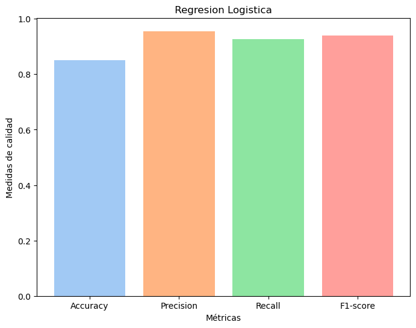

```python
from sklearn.metrics import accuracy_score, precision_score, recall_score, f1_score
import matplotlib.pyplot as plt
import seaborn as sns

# Calcula las métricas de evaluación
accuracy = accuracy_score(y_test, prediction)
precision = precision_score(y_test, prediction, average='weighted')
recall = recall_score(y_test, prediction, average='weighted')
f1 = f1_score(y_test, prediction, average='weighted')

# Redondea las métricas
accuracy = round(accuracy, 4)
precision = round(precision, 4)
recall = round(recall, 4)
f1 = round(f1, 4)

print('Accuracy:', accuracy)
print('Precision:', precision)
print('Recall:', recall)
print('F1-score:', f1)

labels = ['Accuracy', 'Precision', 'Recall', 'F1-score']
values = [accuracy, precision, recall, f1]

palette = sns.color_palette("pastel")

plt.figure(figsize=(8, 6))
plt.bar(labels, values, color=palette)
plt.title(' Regresion Logistica ')
plt.xlabel('Métricas')
plt.ylabel('Medidas de calidad')
plt.show()
```

## Optimización y entrenamiento del modelo Random Forest

```python
mltRandomForest = MultiOutputClassifier(RandomForestClassifier(n_estimators=10), n_jobs=-1)

# Define los parámetros que deseas optimizar para RandomForestClassifier
param_grid = {
    'estimator__n_estimators': [10,20, 30],
    'estimator__max_depth': [None, 20],
}

grid_search = GridSearchCV(mltRandomForest, param_grid, cv=2, scoring='accuracy', verbose=1)
grid_search.fit(X_train_tfidf, y_train)

# Obtiene los mejores parámetros encontrados
best_paramsRF = grid_search.best_params_

# Obtiene el mejor modelo
best_mltRandomForest = grid_search.best_estimator_
best_mltRandomForest.fit(X_train_tfidf, y_train)
print("Best Parameters:", best_paramsRF)
```

```
Fitting 2 folds for each of 6 candidates, totalling 12 fits
Best Parameters: {'estimator__max_depth': None, 'estimator__n_estimators': 30}
```

```python
cv_results_rf = pd.DataFrame(grid_search.cv_results_)
cv_results_rf
```

|  | mean_fit_time | std_fit_time | mean_score_time | std_score_time | param_estimator__max_depth | param_estimator__n_estimators | params | split0_test_score | split1_test_score | mean_test_score | std_test_score | rank_test_score |
| --- | --- | --- | --- | --- | --- | --- | --- | --- | --- | --- | --- | --- |
| 0 | 178.010529 | 1.142975 | 7.347978 | 0.142617 | None | 10 | {'estimator__max_depth': None, 'estimator__n_e... | 0.650568 | 0.649308 | 0.649938 | 0.000630 | 3 |
| 1 | 336.375601 | 9.073203 | 11.925391 | 0.538557 | None | 20 | {'estimator__max_depth': None, 'estimator__n_e... | 0.700819 | 0.697839 | 0.699329 | 0.001490 | 2 |
| 2 | 476.012716 | 5.332431 | 15.821918 | 0.061529 | None | 30 | {'estimator__max_depth': None, 'estimator__n_e... | 0.715082 | 0.717610 | 0.716346 | 0.001264 | 1 |
| 3 | 51.505206 | 0.248922 | 4.323901 | 0.010820 | 20 | 10 | {'estimator__max_depth': 20, 'estimator__n_est... | 0.413333 | 0.419887 | 0.416610 | 0.003277 | 6 |
| 4 | 101.100614 | 0.516982 | 6.640936 | 0.041444 | 20 | 20 | {'estimator__max_depth': 20, 'estimator__n_est... | 0.440789 | 0.433275 | 0.437032 | 0.003757 | 5 |
| 5 | 149.613458 | 0.158203 | 8.936899 | 0.044196 | 20 | 30 | {'estimator__max_depth': 20, 'estimator__n_est... | 0.443701 | 0.439286 | 0.441493 | 0.002208 | 4 |

Calculo de predicciones

```python
predictionRF = best_mltRandomForest.predict(X_test_tfidf)
predictionRF[0]
```

```
array([0, 1, 0, 0, 0, 0, 0, 0, 0, 0, 0, 0, 0, 0, 0, 0, 0, 0, 0, 0, 0, 1,
       0, 0, 0, 0, 0, 0, 0, 0, 0, 0, 0, 0, 0, 0, 0, 0, 0, 0, 0, 0, 0, 0,
       0, 0, 0, 0, 0, 0, 0, 0, 0, 0, 0, 0, 0, 0, 0, 0, 0, 0, 0, 0, 0, 0,
       0, 0, 0, 0, 0, 0, 0, 0, 0, 0, 0, 0, 0])
```

Calculo del Accuracy y del Hamming loss

```python
from sklearn.metrics import hamming_loss
hamming_loss_RF = hamming_loss(y_test, predictionRF)
accuracy_RF = accuracy_score(y_test, predictionRF)

print("Accuracy:", accuracy_RF)
print("Hamming Loss:", hamming_loss_RF)
```

```
Accuracy: 0.7583364346855229
Hamming Loss: 0.0041722216202720085
```

Comparación de resultados de la prediccion y del test

```python
print(predictionRF[7])
print(y_test[7])
```

```
[0 0 0 0 0 0 0 0 0 0 0 0 0 0 0 0 0 0 0 0 0 0 0 0 0 0 0 0 0 0 0 0 0 0 0 0 0
 0 0 0 0 0 0 0 0 0 0 0 0 0 0 0 0 0 0 0 0 1 0 0 0 0 0 0 0 0 0 0 0 0 0 0 0 0
 0 1 0 0 0]
[0 0 0 0 0 0 0 0 0 0 0 0 0 0 0 0 0 0 0 0 0 0 0 0 0 0 0 0 0 0 0 0 0 0 0 0 0
 0 0 0 0 0 0 0 0 0 0 0 0 0 0 0 0 0 0 0 0 1 0 0 0 0 0 0 0 0 0 0 0 0 0 0 0 0
 0 1 0 0 0]
```

```python
y_pred_Clase = np.argmax(predictionRF, axis=-1)
y_test_Clase = np.argmax(y_test, axis=-1)
len(y_test_Clase)

dataframeFinal=pd.DataFrame({'real':y_test_Clase, 'predicción': y_pred_Clase})
np.set_printoptions(formatter={'float': lambda X: "{0:0.0f}".format(X)})
dataframeFinal.head(10)
```

|  | real | predicción |
| --- | --- | --- |
| 0 | 1 | 1 |
| 1 | 1 | 1 |
| 2 | 45 | 45 |
| 3 | 24 | 0 |
| 4 | 1 | 1 |
| 5 | 1 | 1 |
| 6 | 24 | 24 |
| 7 | 57 | 57 |
| 8 | 24 | 24 |
| 9 | 44 | 44 |

```python
from sklearn.metrics import classification_report
print(classification_report(y_test,predictionRF))
```

```
              precision    recall  f1-score   support

           0       0.94      0.61      0.74       313
           1       0.97      0.95      0.96     23880
           2       0.99      0.97      0.98       132
           3       0.95      0.91      0.93      2030
           4       0.97      0.77      0.86      1438
           5       0.99      0.70      0.82      1958
           6       0.94      0.60      0.73       519
           7       1.00      0.42      0.59        89
           8       0.97      0.72      0.83       132
           9       0.99      0.94      0.96      1348
          10       0.96      0.83      0.89      2014
          11       0.99      0.68      0.81       551
          12       1.00      0.98      0.99       729
```

[output cut: 71 more lines]

```
Accuracy: 0.7583
Precision: 0.9713
Recall: 0.8599
F1-score: 0.9043
```

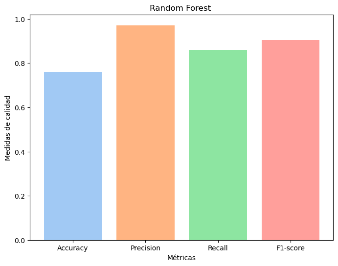

```python
from sklearn.metrics import accuracy_score, precision_score, recall_score, f1_score
import matplotlib.pyplot as plt
import seaborn as sns

# Calcula las métricas de evaluación
accuracy = accuracy_score(y_test,predictionRF)
precision = precision_score(y_test,predictionRF, average='weighted')
recall = recall_score(y_test,predictionRF, average='weighted')
f1 = f1_score(y_test,predictionRF, average='weighted')

# Redondea las métricas
accuracy = round(accuracy, 4)
precision = round(precision, 4)
recall = round(recall, 4)
f1 = round(f1, 4)

print('Accuracy:', accuracy)
print('Precision:', precision)
print('Recall:', recall)
print('F1-score:', f1)

labels = ['Accuracy', 'Precision', 'Recall', 'F1-score']
values = [accuracy, precision, recall, f1]

palette = sns.color_palette("pastel")

plt.figure(figsize=(8, 6))
plt.bar(labels, values, color=palette)
plt.title('Random Forest ')
plt.xlabel('Métricas')
plt.ylabel('Medidas de calidad')
plt.show()
```

### Comparacion de los Hamming Loss

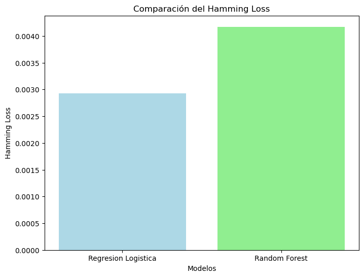

```python
from sklearn.metrics import hamming_loss

hamming_loss = hamming_loss(y_test, prediction)

# Etiquetas de los modelos
modelos = ['Regresion Logistica', 'Random Forest']

# Valores de Hamming Loss
hamming_loss = [hamming_loss, hamming_loss_RF]

# Colores de las barras
colores = ['lightblue', 'lightgreen']

# Crear el gráfico de barras
plt.figure(figsize=(8, 6))
plt.bar(modelos, hamming_loss, color=colores)

# Agregar etiquetas y título
plt.xlabel('Modelos')
plt.ylabel('Hamming Loss')
plt.title('Comparación del Hamming Loss')

# Mostrar el gráfico
plt.show()
```

### Conclusiones

Antes de enviar el texto a entrenar es en ingles y se realizo el limpiado de este, eliminando caracteres especiales, quitando las stopwords e ignorando en el texto todos los caracteres que no tengan codigo ASCII pues se incluia personajes de culturas con distinto abecedario al nuestro , a ese texto se le aplico la lematización para buscar tener el texto más limpio posible.

Para los 2 modelos se realizo un modelo de regresion logistica y un Random Forest, para estos 2 como estamos haciendo modelos con inputs de texto debemos convertirlos a numeros para que los modelos puedan entender de los datos por lo que TfidfVectorizer vectorizamos el texto dandoles un lenght de 2500 features y con eso dividimos los datos de train y test.

Para nuestra regresion logistica se hizo el proceso de optimizacion con un grid search y probando los parametros

**"estimator__C": [0.1, 1, 10], "estimator__solver": ['liblinear', 'lbfgs']**  
Y con eso obtuvimos que la mejor combinación fue C:10 Y solver: liblinear:

Para nuestra rRandom Forest se hizo el proceso de optimizacion con un grid search y probando los parametros

**"n_estimators": [10,20,30] , "max_depth": [None, 20]**

el mejor resultado fue con n_estimators=30 y max_depth=None obtuviendo los siguiente resultados:

**Fase de evaluación obtuvimos:Accuracy= 0.7583 Precision=0.9713 Recall=0.8599 F1-score=0.9043 y un Hamming loss=0.004172**

La Regresión Logística supera al Random Forest en términos de exactitud, recall y F1-score.Sin embargo, el Random Forest tiene una precisión ligeramente mejor que la Regresión Logística.pero los 2 modelos tienen un Hamming Loss bastante bajo, lo que indica que ambos modelos son bastante buenos en la predicción de las etiquetas. de los 2 modelos el mejor termina siendo la regresión logistica.

### Referencias

Ortiz, I. R. H. (2023, diciembre 23). Clasificación de Sentimientos con Procesamiento de Lenguaje Natural y Redes Neuronales Recurrentes (LSTM). Corpus en Español sobre restaurantes. GenSciNet. https://genscinet.com/clasificacion-sentimientos-nlp-lstm-espaniol/

Dagan, G., Keller, F., & Lascarides, A. (2023). Dynamic Planning with a LLM. arXiv preprint arXiv:2308.06391.

Jiang, Q. (2023). Métodos de Clasificación con Python: Aplicaciones Empresariales.

**Dataset:** Ofer, D. (2019). DBPedia Classes [dataset]. Recuperado de: https://www.kaggle.com/datasets/danofer/dbpedia-classes